# Predictive performance of multi-model ensemble forecasts of COVID-19 across European nations

# Abstract

*Background* Short-term forecasts of infectious disease burden can contribute to situational awareness and aid capacity planning. Based on best practice in other fields and recent insights in infectious disease epidemiology, one can maximise the predictive performance of such forecasts if multiple models are combined into an ensemble. Here we report on the performance of ensembles in predicting COVID-19 cases and deaths across Europe between 08 March 2021 and 07 March 2022.

*Methods* We used open-source tools to develop a public European COVID-19 Forecast Hub. We invited groups globally to contribute weekly forecasts for COVID-19 cases and deaths over the next one to four weeks. Forecasts were submitted using standardised quantiles of the predictive distribution. Each week we created an ensemble forecast, where each predictive quantile was calculated as the equally-weighted average (initially the mean and then the median from the 26th of July) of all individual models’ predictive quantiles. We measured the performance of each model using the relative Weighted Interval Score (WIS), comparing models’ forecast accuracy relative to all other models, then scaled against a baseline model of no change. We retrospectively explored alternative methods for ensemble forecasts, including weighted averages based on models’ past predictive performance.

*Results* Over 52 weeks we collected and combined up to 28 forecast models for 32 countries. We found a weekly ensemble had a strong and consistently reliable performance across countries over time. Across all horizons and locations, the ensemble performed better on scaled relative WIS than 83% of participating models’ forecasts of incident cases (with a total N=862), and 91% of participating models’ forecasts of deaths (N=746). Across a one to four week time horizon, ensemble performance declined with longer forecast periods when forecasting cases, but remained stable over four weeks for incident death forecasts. In every forecast across 32 countries, the ensemble outperformed 50% of submitted models when forecasting either cases or deaths, frequently outperforming all of its individual component models. Among several choices of ensemble methods we found that the most influential and best choice was to use a median average of models instead of using the mean, regardless of methods of weighting component forecast models.

*Conclusions* Our results support the use of combining forecasts from individual models into an ensemble in order to improve predictive performance across epidemiological targets and populations during infectious disease epidemics. Our findings suggested that for an emerging pathogen with many individual models, median ensemble methods may improve predictive performance more than mean ensemble methods. Our findings also highlight that forecast consumers should place more weight on incident death forecasts versus incident case forecasts for forecast horizons greater than two weeks.

*Code and data availability* All data and code are publicly available on Github: covid19-forecast-hub-europe/euro-hub-ensemble.

*This document was generated on* 2022-03-28

# Background

Epidemiological forecasts make quantitative statements about a disease outcome in the near future. Forecasting targets can include measures of prevalent or incident disease and its severity, for some population over a specified time horizon. Researchers, policy makers, and the general public have used such forecasts to understand and respond to the global outbreaks of COVID-19 since early 2020 [1]. Forecasters use a variety of methods and models for creating and publishing forecasts, varying in both defining the forecast outcome and in reporting the probability distribution of outcomes [2], [3]. Such variation between forecasts makes it difficult to compare predictive performance between forecast models. These barriers to comparing and evaluating forecasts make it difficult to derive objective arguments for using one forecast over another. This hampers the selection of a representative forecast and hinders finding a reliable basis for decisions.

Standardising forecasts allows for combining multiple forecasts into a single ensemble with the potential for an improved predictive performance. Evidence from previous efforts in multi-model infectious disease forecasting suggests that forecasts from an ensemble of models can be consistently high performing compared to any one of the component models [10]–[12]. Elsewhere, weather forecasting has a long-standing use of building ensembles of models using diverse methods with standardised data and formatting in order to improve performance [13], [14].

The European COVID-19 Forecast Hub [15] is a project to collate short term forecasts of COVID-19 across 32 countries in the European region. The Hub is funded and supported by the European Centre for Disease Prevention and Control (ECDC), with the primary aim to provide reliable information about the near-term epidemiology of the COVID-19 pandemic to the research and policy communities and the general public. Second, the Hub aims to create infrastructure for storing and analysing epidemiological forecasts made in real time by diverse research teams and methods across Europe. Third, the Hub aims to maintain a community of infectious disease modellers underpinned by open science principles.

We started formally collating and combining contributions to the European Forecast Hub in March 2021. Here, we investigate the predictive performance of an ensemble of all forecasts contributed to the Hub in real time each week, as well as the performance of variations of ensemble methods created retrospectively.

# Methods

We developed infrastructure to host and analyse forecasts, focussing on compatibility with the US [16], [17] and the German and Polish COVID-19 [18] forecast hubs.

### Forecast targets and standardisation

We sought forecasts for two measures of COVID-19 incidence: the total reported number of cases and deaths per week. We considered forecasts for 32 countries in Europe, including all countries of the European Union and European Free Trade Area, and the United Kingdom. We compared forecasts against observed data reported by Johns Hopkins University (JHU, [19]). JHU data included a mix of national and aggregated subnational data for the 32 countries in the Hub. Incidence was aggregated over the Morbidity and Mortality Weekly Report (MMWR) epidemiological week definition of Sunday through Saturday.

When predicting any single forecast target, teams could express uncertainty by submitting predictions across a range of a pre-specified set of 23 quantiles in the probability distribution. Teams could also submit a single point forecast without uncertainty. At the first submission we asked teams to add a single set of metadata briefly describing the forecasting team and methods. No restrictions were placed on who could submit forecasts, and to increase participation we actively contacted known forecasting teams across Europe and the US and advertised among the ECDC network. Teams submitted a broad spectrum of model types, ranging from mechanistic to empirical models, agent-based and statistical models, and ensembles of multiple quantitative or qualitative models (described at https://covid19forecasthub.eu/community.html). We maintain a full project specification with a detailed submissions protocol [20].

With the complete dataset for the latest forecasting week available each Sunday, teams typically submitted forecasts to the hub on Monday. We implemented an automated validation programme to check that each new forecast conformed to standardised formatting. The validation step ensured a monotonic increase of predictions with each increasing quantile, integer-valued counts of predicted cases, as well as consistent date and location definitions.

Each week we built an ensemble of all forecasts updated after all forecasts had been validated. From the first week of forecasting from 8 March 2021, the ensemble method for summarising across forecasts was the arithmetic mean of all models at each predictive quantile for a given location, target, and horizon. From 26 July 2021 onwards the ensemble instead used a median of all predictive quantiles, in order to mitigate the wide uncertainty produced by some highly anomalous forecasts. We created an open and publicly accessible interface to the forecasts and ensemble, including an online visualisation tool allowing viewers to see past data and interact with one or multiple forecasts for each country and target for up to four weeks’ horizon[21]. All forecast and meta data are freely available and held on Zoltar, a platform for hosting epidemiological forecasts [22], [23].

### Forecast evaluation

We evaluated all previous forecasts against actual observed values for each model, stratified by the forecast horizon, location, and target. We calculated scores using the scoringutils R package [24]. We removed any forecast surrounding (in the week of the first week after) a strongly anomalous data point. We defined anomalous as where any subsequent data release revised that data point by over 5%.

For each model, we established its overall predictive performance using the weighted interval score (WIS) and the accuracy of its prediction boundaries as the coverage of the predictive intervals. We calculated coverage at a given interval level k, where $k\in[0,1]$, as the proportion $p$ of observations that fell within the corresponding central predictive intervals across locations and forecast dates. A perfectly calibrated model would have $p=k$ at all 11 levels (corresponding to 22 quantiles excluding the median). An under confident model at level $k$ would have $p>k$, i.e. more observations fall within a given interval than expected. In contrast, an overconfident model at level $k$ would have $p<k$, i.e. fewer observations fall within a given interval than expected. We here focus on coverage at the $k=0.5$ and $k=0.95$ level.

We assessed weekly forecasts using the WIS, across all quantiles that were being gathered [25]. The WIS is a strictly proper scoring rule, that is, it is optimised for predictions that come from the data-generating model. As a consequence, the WIS encourages forecasters to report predictions representing their true belief about the future [26]. The WIS represents an approach to scoring forecasts based on uncertainty represented as forecast values across a set of quantiles [25]. The WIS represents a parsimonious approach to scoring forecasts when only quantiles are available. Each forecast for a given location and date is scored based on an observed count of weekly incidence, the median of the predictive distribution and the width of the predictive upper and lower quantiles corresponding to the central predictive interval level (see [25]).

We then took the relative WIS of each model and scaled this against the relative WIS of a baseline model, for each forecast target, location, date, and horizon. The baseline model assumes case or death counts stay the same as the latest data point over all future horizons, with expanding uncertainty, described previously in [27]. Here we report the relative WIS of each model with respect to the baseline model.

#### Ensemble methods

We retrospectively explored alternative methods for combining forecasts for each target at each week. A natural way to combine probability distributions available in a quantile format, such as the ones collated in the European COVID-19 Forecast Hub, is [28]
$$F^{-1}(\alpha) = \sum_{i=1}^{n}w_i F_i^{-1}(\alpha)$$

Where $F_{1} \ldots F_{n}$ are the cumulative distribution functions of the individual probability distributions (in our case, the predictive distributions of each forecast model $i$ contributed to the hub), $w_i$ are a set of weights in $[0,1]$; and $\alpha$ are the quantile levels such that

$$F^{-1}(\alpha) = \mathrm{inf} \{t : F_i(t) \geq \alpha \}$$

Different ensemble choices then mainly translate to the choice of weights $w_i$. The simplest choice of weights $w_i$ is to set them all equal so that they sum up to 1, $w_i=1/n$, resulting in an arithmetic mean ensemble. However, with this method a single outlier can have a very strong effect on the ensemble forecast. To avoid this overrepresentation, we can choose a set of weights to apply to forecasts before they are combined at each quantile level. Numerous options exist for choosing these weights with the aim to maximise predictive performance, including choosing weights to reflect each forecast’s past performance (thereby moving from an untrained to a trained ensemble). A straightforward choice is so-called inverse score weighting, which was recently found in the US to outperform unweighted scores during some time periods [29] but not confirmed in a similar study in Germany and Poland Poland [7]. In this case, the weights are calculated as
$$w_i = \frac{1}{S_i}$$

where $S_i$ reflects the forecast skill of forecaster $i$, normalised so that weights sum to 1.

# Results

We collected forecasts submitted weekly in real time over the 52 week period from 08 March 2021 to 07 March 2022. Each week we used all available forecasts to create a weekly real-time ensemble model (referred to as “the ensemble” from here on) for each of the 256 possible forecast targets: incident cases and deaths in 32 locations over the following one through four weeks. The ensemble model was an unweighted average from March through July 2021 and then an unweighted median (figure 0).

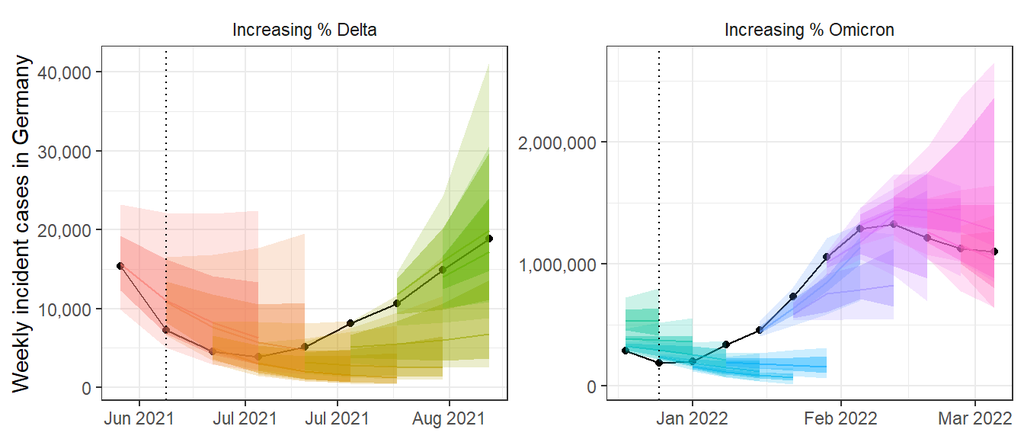

*Ensemble forecasts of weekly incident cases in Germany over periods of increasing SARS-CoV-2 variants Delta (B.1.617.2, left) and Omicron (B.1.1.529, right). Black indicates observed data. Coloured ribbons represent each weekly forecast of 1-4 weeks ahead (showing median, 50%, and 90% probability). For each variant, forecasts are shown over an x-axis bounded by the earliest dates at which 5% and 99% of sequenced cases were identified as the respective variant of concern, while vertical dotted lines indicate the approximate date that the variant reached dominance (>50% sequenced cases).*

The number of models contributing to each ensemble forecast varied over time and by forecasting target (SI figure 1). Over the whole study period 26 independently participating forecasting teams contributed results from 28 unique forecasting models. While not all modellers created forecasts for all locations, horizons, or variables, no ensemble forecast was composed of less than 3 independent models. At most, 15 models contributed forecasts for cases in Germany at the 1 week horizon, with an accumulated 592 forecasts for that single target over the study period (with the ensemble of all models in Germany shown in figure 0). In contrast, deaths in Finland at the 2 week horizon saw the smallest number of forecasts, with only 6 independent models contributing a total 24 forecasts. Similarly, not all teams forecast across all quantiles of the predictive distribution for each target, with only 23 models providing the full set of 23 quantiles.

Using all models and the ensemble, we created 2106 forecasting scores where each score summarises a unique combination of forecasting model, variable, country, and week ahead horizon (SI figure 2). The ensemble of all models performed well compared to both its component models and the baseline. By relative WIS scaled against a baseline of 1 (where a score <1 indicates outperforming the baseline), the median score for participating models across all submitted forecasts was 1.04, while the median score of forecasts from the ensemble model was 0.71. Across all horizons and locations, the ensemble performed better on scaled relative WIS than 83% of participating model scores when forecasting cases (with a total N=862), and 91% of participating model scores for forecasts of incident deaths (N=746).

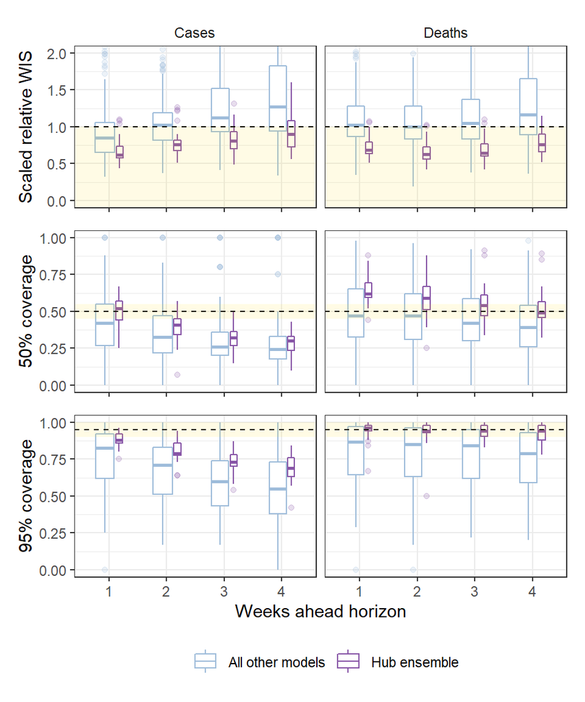

*Performance of short-term forecasts aggregated across all individually submitted models and the Hub ensemble, by horizon, forecasting cases (left) and deaths (right). Performance measured by relative weighted interval score scaled against a baseline (dotted line, 1), and coverage of uncertainty at the 50% and 95% levels. Boxplot, with width proportional to number of observations, show interquartile ranges with outlying scores as faded points. The target range for each set of scores is shaded in yellow.*

The performance of individual and ensemble forecasts varied by length of the forecast horizon (Figure 1). At each horizon, the typical performance of the ensemble outperformed both the baseline model and the aggregated scores of all its component models, although we saw wide variation between individual models in performance across horizons.

Both individual models and the ensemble saw a trend of worsening performance at longer horizons when forecasting cases, while performance remained more stable when estimating deaths. By scaled relative WIS, the median performance of the ensemble across locations worsened from 0.62 for one-week ahead forecasts to 0.9 when forecasting four weeks ahead. Performance for forecasts of deaths was more stable over one through four weeks, with median ensemble performance moving from 0.685 to 0.76 across the four week horizons.

We observed similar trends in performance across horizon when considering how well the ensemble was calibrated with respect to the observed data. At one week ahead the case ensemble was well calibrated (ca. 50% and 95% nominal coverage at the 50% and 95% levels respectively). This did not hold at longer forecast horizons as the case forecasts became increasingly over-confident. Meanwhile, the ensemble of death forecasts was well calibrated at the 95% level across all horizons, and the calibration of death forecasts at the 50% level increased in accuracy with lengthening horizons.

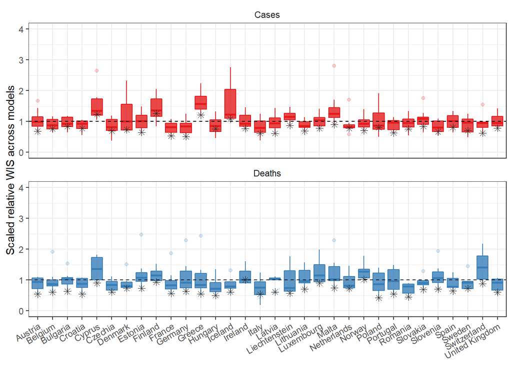

*Performance of short-term forecasts across models and median ensemble (asterisk), by country, forecasting cases (top) and deaths (bottom) for two-week ahead forecasts, according to the relative weighted interval score. Boxplots show interquartile ranges, with outliers as faded points, and the ensemble model performance is marked by an asterisk. y-axis is cut-off to an upper bound of 4 for readability.*

The ensemble also performed consistently well in comparison to individual models when forecasting across countries (figure 2). Across 32 countries, on aggregate forecasting for one through four weeks, when forecasting cases the ensemble oupterformed 75% of component models in 21 countries, and outperformed all available models in 3 countries. When forecasting deaths, the ensemble outperformed 75% and 100% of models in 30 and 9 countries respectively. Considering only the the two-week horizon shown in figure 2, the ensemble of case forecasts outperformed 75% models in 24 countries and all models in only 12 countries. At the two-week horizon for forecasts of deaths, the ensemble outperformed 75% and 100% of its component models in 30 and 26 countries respectively.

Predictive performance of main ensembles, as measured by the scaled relative WIS.

| Horizon | Weighted mean | Weighted median | Unweighted mean | Unweighted median |
| --- | --- | --- | --- | --- |
| **Cases** |  |  |  |  |
| 1 week | 0.59 | 0.62 | 0.59 | 0.61 |
| 2 weeks | 0.67 | 0.67 | 0.67 | 0.67 |
| 3 weeks | 0.79 | 0.70 | 0.81 | 0.71 |
| 4 weeks | 1.06 | 0.75 | 1.09 | 0.79 |
| **Deaths** |  |  |  |  |
| 1 week | 0.63 | 0.59 | 1.00 | 0.59 |
| 2 weeks | 0.57 | 0.54 | 0.81 | 0.53 |
| 3 weeks | 0.64 | 0.56 | 0.83 | 0.54 |
| 4 weeks | 0.83 | 0.64 | 0.82 | 0.62 |

[1]

P. van Basshuysen, L. White, D. Khosrowi, and M. Frisch, “Three Ways in Which Pandemic Models May Perform a Pandemic,” *Erasmus Journal for Philosophy and Economics*, vol. 14, no. 1, pp. 110-127-110-127, 2021, doi: 10.23941/ejpe.v14i1.582.

[2]

J. Zelner, J. Riou, R. Etzioni, and A. Gelman, “Accounting for uncertainty during a pandemic,” *Patterns*, vol. 2, no. 8, 2021, doi: 10.1016/j.patter.2021.100310.

[3]

L. P. James, J. A. Salomon, C. O. Buckee, and N. A. Menzies, “The Use and Misuse of Mathematical Modeling for Infectious Disease Policymaking: Lessons for the COVID-19 Pandemic,” *Medical Decision Making*, vol. 41, no. 4, pp. 379–385, 2021, doi: 10.1177/0272989X21990391.

[4]

N. G. Reich *et al.*, “A collaborative multiyear, multimodel assessment of seasonal influenza forecasting in the United States,” *Proceedings of the National Academy of Sciences*, vol. 116, no. 8, pp. 3146–3154, 2019, doi: 10.1073/pnas.1812594116.

[5]

CDC, “Coronavirus Disease 2019 (COVID-19),” *Centers for Disease Control and Prevention*. 2020. Accessed: Jan. 09, 2022. [Online]. Available: https://www.cdc.gov/coronavirus/2019-ncov/science/forecasting/forecasting.html

[6]

E. L. Ray *et al.*, “Ensemble Forecasts of Coronavirus Disease 2019 (COVID-19) in the U.S.” Cold Spring Harbor Laboratory Press, p. 2020.08.19.20177493, 2020. doi: 10.1101/2020.08.19.20177493.

[7]

J. Bracher *et al.*, “A pre-registered short-term forecasting study of COVID-19 in Germany and Poland during the second wave,” *Nature Communications*, vol. 12, no. 1, p. 5173, 2021, doi: 10.1038/s41467-021-25207-0.

[8]

S. Funk *et al.*, “Short-term forecasts to inform the response to the Covid-19 epidemic in the UK,” *medRxiv*, p. 2020.11.11.20220962, 2020, doi: 10.1101/2020.11.11.20220962.

[9]

M. Bicher *et al.*, “Supporting COVID-19 Policy-Making with a Predictive Epidemiological Multi-Model Warning System,” *medRxiv*, p. 2020.10.18.20214767, 2021, doi: 10.1101/2020.10.18.20214767.

[10]

N. G. Reich *et al.*, “Accuracy of real-time multi-model ensemble forecasts for seasonal influenza in the U.S,” *PLoS computational biology*, vol. 15, no. 11, p. e1007486, 2019, doi: 10.1371/journal.pcbi.1007486.

[11]

M. A. Johansson *et al.*, “An open challenge to advance probabilistic forecasting for dengue epidemics,” *Proceedings of the National Academy of Sciences*, vol. 116, no. 48, pp. 24268–24274, 2019, doi: 10.1073/pnas.1909865116.

[12]

C. Viboud *et al.*, “The RAPIDD ebola forecasting challenge: Synthesis and lessons learnt,” *Epidemics*, vol. 22, pp. 13–21, 2018, doi: 10.1016/j.epidem.2017.08.002.

[13]

R. Buizza, “Introduction to the special issue on ‘25 years of ensemble forecasting’,” *Quarterly Journal of the Royal Meteorological Society*, vol. 145, no. S1, pp. 1–11, 2019, doi: 10.1002/qj.3370.

[14]

K. R. Moran *et al.*, “Epidemic Forecasting is Messier Than Weather Forecasting: The Role of Human Behavior and Internet Data Streams in Epidemic Forecast,” *The Journal of Infectious Diseases*, vol. 214, no. suppl_4, pp. S404–S408, 2016, doi: 10.1093/infdis/jiw375.

[15]

European Covid-19 Forecast Hub, “European COVID-19 Forecast Hub.” covid19-forecast-hub-europe, 2021.Available: https://github.com/covid19-forecast-hub-europe/covid19-forecast-hub-europe

[16]

E. Cramer *et al.*, “Reichlab/Covid19-forecast-hub: Release for Zenodo, 20210816,” 2021, doi: 10.5281/zenodo.5208210.

[17]

S. Y. Wang *et al.*, “Reichlab/covidHubUtils: Repository release for Zenodo,” 2021, doi: 10.5281/zenodo.5207940.

[18]

J. Bracher *et al.*, “The German and Polish COVID-19 Forecast Hub.” 2020.Available: https://github.com/KITmetricslab/covid19-forecast-hub-de

[19]

E. Dong, H. Du, and L. Gardner, “An interactive web-based dashboard to track COVID-19 in real time,” *The Lancet Infectious Diseases*, vol. 20, no. 5, pp. 533–534, 2020, doi: 10.1016/S1473-3099(20)30120-1.

[20]

European Covid-19 Forecast Hub, “Covid19-forecast-hub-europe: Wiki,” *GitHub*. Available: https://github.com/covid19-forecast-hub-europe/covid19-forecast-hub-europe

[21]

European Covid-19 Forecast Hub, “European Covid-19 Forecast Hub.” Available: https://covid19forecasthub.eu/index.html

[22]

EpiForecasts, “Project: ECDC European COVID-19 Forecast Hub - Zoltar.” 2021.Available: https://www.zoltardata.com/project/238

[23]

N. G. Reich, M. Cornell, E. L. Ray, K. House, and K. Le, “The Zoltar forecast archive, a tool to standardize and store interdisciplinary prediction research,” *Scientific Data*, vol. 8, no. 1, p. 59, 2021, doi: 10.1038/s41597-021-00839-5.

[24]

Nikos I Bosse, Sam Abbott, EpiForecasts, and Sebastian Funk, “Scoringutils: Utilities for Scoring and Assessing Predictions.” 2020.Available: https://github.com/epiforecasts/scoringutils

[25]

J. Bracher, E. L. Ray, T. Gneiting, and N. G. Reich, “Evaluating epidemic forecasts in an interval format,” *PLOS Computational Biology*, vol. 17, no. 2, p. e1008618, 2021, doi: 10.1371/journal.pcbi.1008618.

[26]

T. Gneiting and A. E. Raftery, “Strictly Proper Scoring Rules, Prediction, and Estimation,” *Journal of the American Statistical Association*, vol. 102, no. 477, pp. 359–378, 2007, doi: 10.1198/016214506000001437.

[27]

E. Y. Cramer *et al.*, “Evaluation of individual and ensemble probabilistic forecasts of COVID-19 mortality in the US,” *medRxiv*, p. 2021.02.03.21250974, 2021, doi: 10.1101/2021.02.03.21250974.

[28]

C. Genest, “Vincentization Revisited,” *The Annals of Statistics*, vol. 20, no. 2, pp. 1137–1142, 1992, Accessed: Jan. 09, 2022. [Online]. Available: https://www.jstor.org/stable/2242003

[29]

J. W. Taylor and K. S. Taylor, “Combining Probabilistic Forecasts of COVID-19 Mortality in the United States,” *European Journal of Operational Research*, 2021, doi: 10.1016/j.ejor.2021.06.044.